# WordCloud Analysis of Australia Dataset

## Overview

This document demonstrates word cloud analysis and text mining techniques using a synthetic dataset about Australia. The analysis covers:

- Text preprocessing and tokenization
- Word frequency analysis
- Word cloud generation
- Category-wise text analysis
- Bigram analysis
- Document-term matrix creation

The dataset contains multiple text files covering different aspects of Australia including geography, cities, wildlife, culture, tourism, history, economy, and sports.

## Libraries and Data Loading

```r
pkgs <- c("tidyverse", "tidytext", "tm", "wordcloud", "RColorBrewer", "SnowballC")
for (p in pkgs) if (!requireNamespace(p, quietly = TRUE)) install.packages(p, repos = "https://cloud.r-project.org")

library(tidyverse)
library(tidytext)
library(tm)
library(wordcloud)
library(RColorBrewer)
library(SnowballC)
```

```r
# Robust dataset path resolution for multiple render locations
candidates <- c(
  tryCatch(here::here("09-04-WordCloud", "Australia-Dataset"), error = function(e) NA_character_),
  file.path("09-04-WordCloud", "Australia-Dataset"),
  "Australia-Dataset",
  file.path("..", "09-04-WordCloud", "Australia-Dataset")
)
root_dir <- candidates[which(dir.exists(candidates))][1]
stopifnot(!is.na(root_dir))

read_texts <- function(root_dir) {
  files <- list.files(root_dir, pattern = "\\.txt$", full.names = TRUE)
  stopifnot(length(files) > 0)
  tibble(
    doc_id = basename(files),
    path = files,
    category = dplyr::case_when(
      grepl("geography", tolower(files)) ~ "Geography",
      grepl("cities", tolower(files)) ~ "Cities",
      grepl("wildlife", tolower(files)) ~ "Wildlife",
      grepl("culture", tolower(files)) ~ "Culture",
      grepl("tourism", tolower(files)) ~ "Tourism",
      grepl("history", tolower(files)) ~ "History",
      grepl("economy", tolower(files)) ~ "Economy",
      grepl("sports", tolower(files)) ~ "Sports",
      TRUE ~ "Other"
    ),
    text = purrr::map_chr(files, ~ paste(readLines(.x, warn = FALSE, encoding = "UTF-8"), collapse = " \n "))
  )
}

docs <- read_texts(root_dir)
```

## Dataset Overview

```r
cat("Dataset contains", nrow(docs), "documents\n")
```

```
## Dataset contains 8 documents
```

```r
cat("Categories:", paste(unique(docs$category), collapse = ", "), "\n")
```

```
## Categories: Cities, Culture, Economy, Geography, History, Sports, Tourism, Wildlife
```

```r
cat("Total characters:", sum(nchar(docs$text)), "\n")
```

```
## Total characters: 14990
```

```r
cat("Average document length:", round(mean(nchar(docs$text))), "characters\n")
```

```
## Average document length: 1874 characters
```

```r
# Show document summary
docs %>%
  mutate(doc_length = nchar(text)) %>%
  select(doc_id, category, doc_length) %>%
  arrange(desc(doc_length))
```

| doc_id | category | doc_length |
| --- | --- | --- |
| australia_sports.txt | Sports | 2134 |
| australia_history.txt | History | 2043 |
| australia_tourism.txt | Tourism | 2042 |
| australia_economy.txt | Economy | 1976 |
| australia_culture.txt | Culture | 1901 |
| australia_wildlife.txt | Wildlife | 1835 |
| australia_cities.txt | Cities | 1541 |
| australia_geography.txt | Geography | 1518 |

## Text Preprocessing and Tokenization

```r
# Tokenize and clean the text
tokens <- docs %>%
  mutate(text_lower = stringr::str_to_lower(text)) %>%
  tidytext::unnest_tokens(token, text_lower)

# Remove stop words and filter tokens
tokens_filtered <- tokens %>%
  anti_join(tidytext::stop_words, by = c("token" = "word")) %>%
  filter(stringr::str_detect(token, "^[a-z]+$"), nchar(token) >= 3)

cat("Total tokens after filtering:", nrow(tokens_filtered), "\n")
```

```
## Total tokens after filtering: 1228
```

```r
cat("Unique words after filtering:", length(unique(tokens_filtered$token)), "\n")
```

```
## Unique words after filtering: 665
```

## Word Frequency Analysis

```r
# Get word frequencies
word_freq <- tokens_filtered %>%
  count(token, sort = TRUE)

# Display top words
head(word_freq, 20)
```

| token | n |
| --- | --- |
| australia | 23 |
| australian | 17 |
| world | 16 |
| culture | 11 |
| country | 10 |
| major | 10 |
| natural | 10 |
| indigenous | 9 |
| national | 9 |
| unique | 9 |

[output cut: 10 more lines]

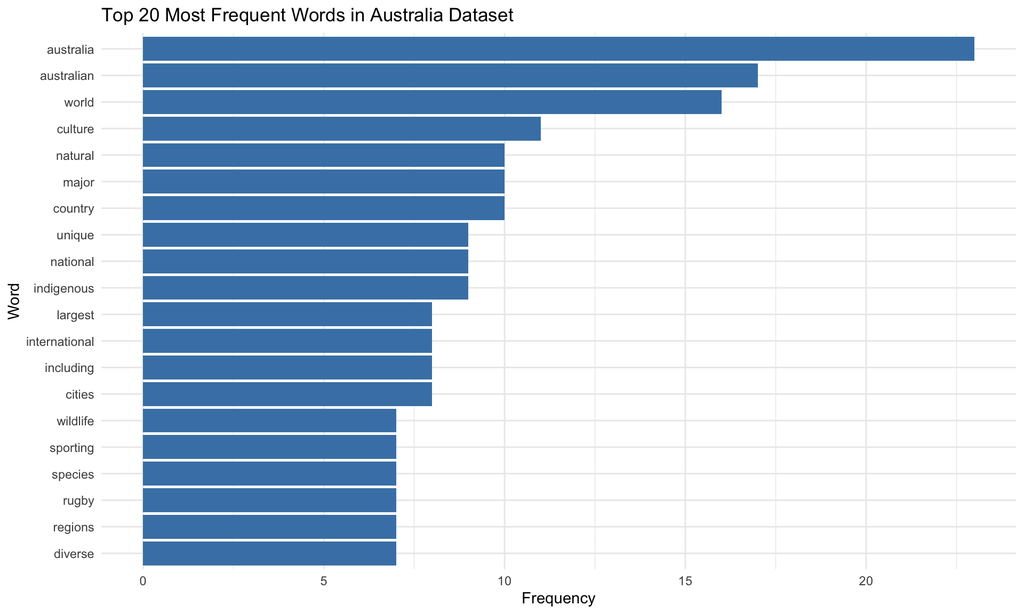

```r
# Create word frequency plot
this_file <- knitr::current_input()
module_dir <- dirname(normalizePath(this_file))
img_dir <- file.path(module_dir, "images")
dir.create(img_dir, showWarnings = FALSE, recursive = TRUE)

save_plot <- function(p, filename, width = 10, height = 6) {
  p_out <- p + theme_bw() + theme(plot.background = element_rect(fill = "white", color = NA), panel.background = element_rect(fill = "white"))
  ggsave(filename = file.path(img_dir, filename), plot = p_out, width = width, height = height, dpi = 150, bg = "white")
}

p1 <- word_freq %>%
  slice_max(n, n = 20) %>%
  mutate(token = reorder(token, n)) %>%
  ggplot(aes(token, n)) +
  geom_col(fill = "steelblue") +
  coord_flip() +
  labs(title = "Top 20 Most Frequent Words in Australia Dataset",
       x = "Word", y = "Frequency") +
  theme_minimal()

save_plot(p1, "word_frequency_plot.png")
p1
```

## Word Cloud Generation

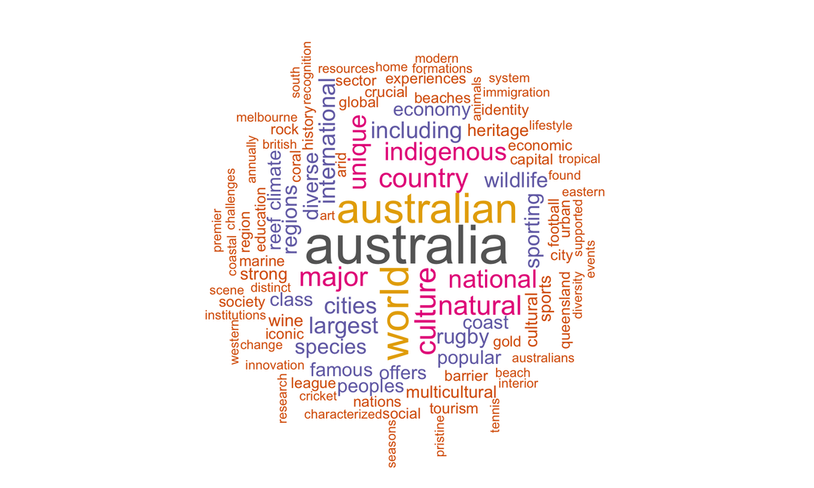

```r
# Create basic word cloud
wordcloud(words = word_freq$token,
          freq = word_freq$n,
          max.words = 100,
          random.order = FALSE,
          rot.per = 0.35,
          colors = brewer.pal(8, "Dark2"))
```

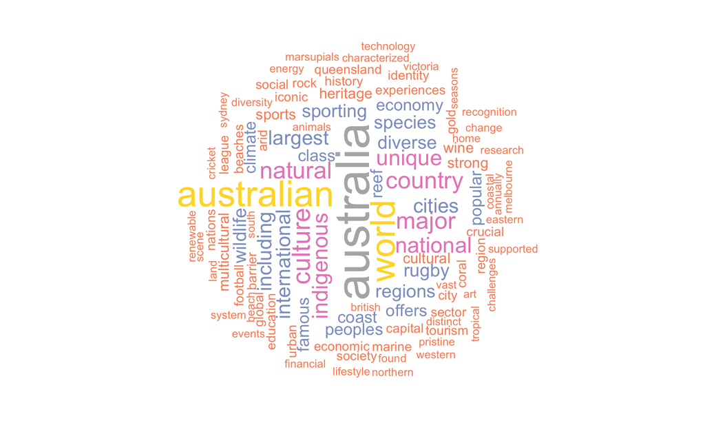

```r
# Create word cloud with different colors
wordcloud(words = word_freq$token,
          freq = word_freq$n,
          max.words = 100,
          random.order = FALSE,
          rot.per = 0.35,
          colors = brewer.pal(8, "Set2"))
```

## Category-wise Analysis

```r
# Category-wise word frequencies
category_freq <- tokens_filtered %>%
  count(category, token, sort = TRUE) %>%
  group_by(category) %>%
  slice_max(n, n = 10) %>%
  ungroup()

# Display top words by category
category_freq %>%
  group_by(category) %>%
  slice_head(n = 5) %>%
  ungroup()
```

| category | token | n |
| --- | --- | --- |
| Cities | cities | 6 |
| Cities | capital | 4 |
| Cities | city | 3 |
| Cities | cultural | 3 |
| Cities | beaches | 2 |
| Culture | australian | 10 |
| Culture | culture | 5 |
| Culture | indigenous | 3 |
| Culture | world | 3 |
| Culture | art | 2 |

[output cut: 30 more lines]

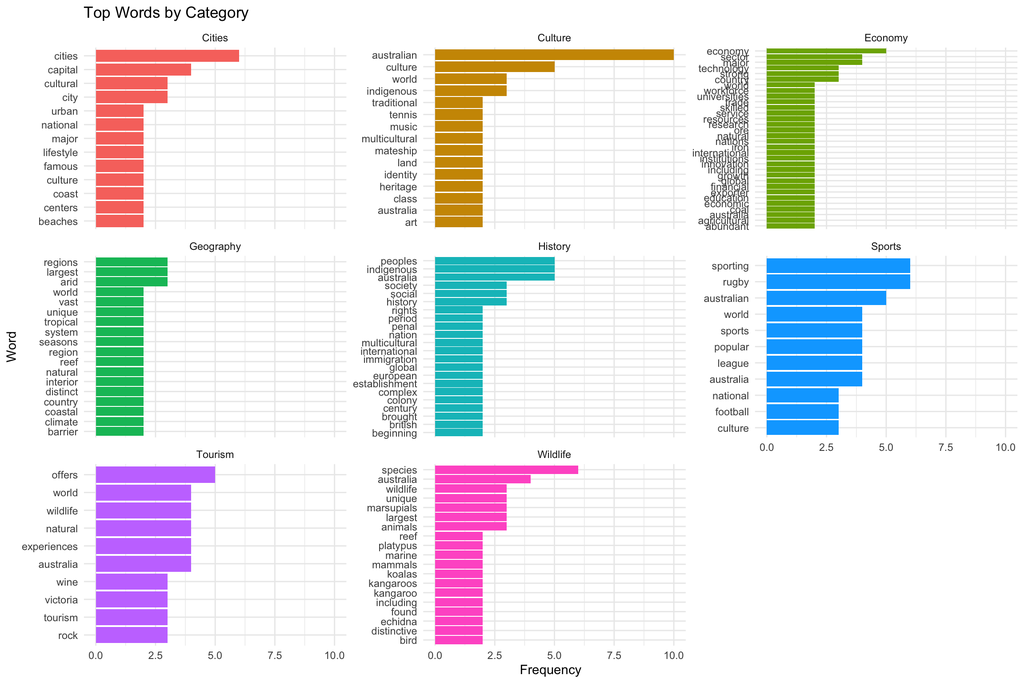

```r
# Top words by category plot
p2 <- category_freq %>%
  mutate(token = tidytext::reorder_within(token, n, category)) %>%
  ggplot(aes(token, n, fill = category)) +
  geom_col(show.legend = FALSE) +
  facet_wrap(~ category, scales = "free_y") +
  tidytext::scale_x_reordered() +
  coord_flip() +
  labs(title = "Top Words by Category",
       x = "Word", y = "Frequency") +
  theme_minimal()

save_plot(p2, "word_frequency_by_category.png")
p2
```

## Bigram Analysis

```r
# Extract bigrams
bigrams <- docs %>%
  mutate(text_lower = stringr::str_to_lower(text)) %>%
  tidytext::unnest_tokens(bigram, text_lower, token = "ngrams", n = 2)

# Clean bigrams
bigrams_clean <- bigrams %>%
  tidyr::separate(bigram, c("w1", "w2"), sep = " ", fill = "right", remove = FALSE) %>%
  filter(!is.na(w2)) %>%
  anti_join(tidytext::stop_words, by = c("w1" = "word")) %>%
  anti_join(tidytext::stop_words, by = c("w2" = "word")) %>%
  count(bigram, sort = TRUE)

# Display top bigrams
head(bigrams_clean, 20)
```

| bigram | n |
| --- | --- |
| world class | 6 |
| australian culture | 5 |
| indigenous peoples | 4 |
| barrier reef | 3 |
| climate change | 3 |
| natural resources | 3 |
| renewable energy | 3 |
| sporting events | 3 |
| world's largest | 3 |
| abundant natural | 2 |

[output cut: 10 more lines]

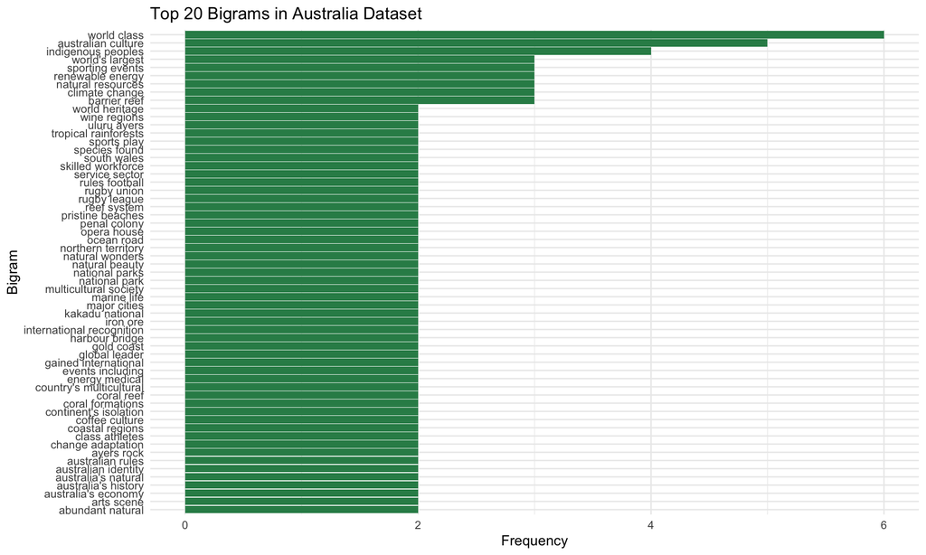

```r
# Top bigrams plot
p3 <- bigrams_clean %>%
  slice_max(n, n = 20) %>%
  mutate(bigram = reorder(bigram, n)) %>%
  ggplot(aes(bigram, n)) +
  geom_col(fill = "seagreen") +
  coord_flip() +
  labs(title = "Top 20 Bigrams in Australia Dataset",
       x = "Bigram", y = "Frequency") +
  theme_minimal()

save_plot(p3, "bigram_frequency_plot.png")
p3
```

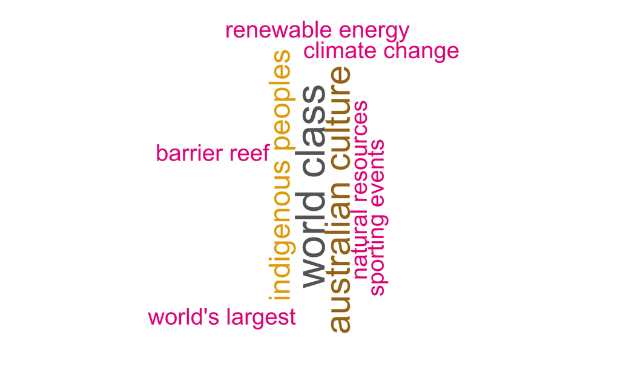

```r
# Bigram word cloud
wordcloud(words = bigrams_clean$bigram,
          freq = bigrams_clean$n,
          max.words = 50,
          random.order = FALSE,
          rot.per = 0.35,
          colors = brewer.pal(8, "Dark2"))
```

## Document-Term Matrix

```r
# Create document-term matrix
dtm <- tokens_filtered %>%
  count(doc_id, token) %>%
  tidytext::cast_dtm(document = doc_id, term = token, value = n)

# Display matrix dimensions
cat("Document-term matrix dimensions:", dim(dtm), "\n")
```

```
## Document-term matrix dimensions: 8 665
```

```r
cat("Sparsity:", round(100 * (1 - length(dtm$v) / (dtm$nrow * dtm$ncol)), 2), "%\n")
```

```
## Sparsity: 82.2 %
```

```r
# Show matrix summary
inspect(dtm[1:3, 1:10])
```

```
## <<DocumentTermMatrix (documents: 3, terms: 10)>>
## Non-/sparse entries: 14/16
## Sparsity           : 53%
## Maximal term length: 10
## Weighting          : term frequency (tf)
## Sample             :
##                        Terms
## Docs                    adelaide amenities arts australia australian beaches
##   australia_cities.txt         1         1    1         1          1       2
##   australia_culture.txt        0         0    1         2         10       0
##   australia_economy.txt        0         0    0         2          0       0
##                        Terms
## Docs                    beautiful boasts bridge brisbane
##   australia_cities.txt          1      1      1        1
##   australia_culture.txt         0      0      0        0
##   australia_economy.txt         0      0      0        0
```

## Summary Statistics

```r
# Dataset summary
cat("Dataset Summary:\n")
```

```
## Dataset Summary:
```

```r
cat("Total documents:", nrow(docs), "\n")
```

```
## Total documents: 8
```

```r
cat("Total unique words:", nrow(word_freq), "\n")
```

```
## Total unique words: 665
```

```r
cat("Total bigrams:", nrow(bigrams_clean), "\n")
```

```
## Total bigrams: 691
```

```r
cat("Document-term matrix dimensions:", dim(dtm), "\n")
```

```
## Document-term matrix dimensions: 8 665
```

```r
# Word frequency distribution
word_freq %>%
  summarise(
    min_freq = min(n),
    max_freq = max(n),
    mean_freq = round(mean(n), 2),
    median_freq = median(n)
  )
```

| min_freq | max_freq | mean_freq | median_freq |
| --- | --- | --- | --- |
| 1 | 23 | 1.85 | 1 |

## Conclusion

This analysis demonstrates various text mining and word cloud techniques using the Australia dataset:

1. **Text Preprocessing**: Successfully tokenized and cleaned the text data
2. **Word Frequency Analysis**: Identified the most common words across all documents
3. **Word Cloud Visualization**: Created multiple word cloud visualizations with different color schemes
4. **Category Analysis**: Analyzed word frequencies within different document categories
5. **Bigram Analysis**: Extracted and analyzed two-word phrases
6. **Document-Term Matrix**: Created a matrix representation for further analysis